# ThinkInteractionsDemo.R

Mark.vdWiel

2023-09-21

# Think Interactions

Script: Mark van de Wiel, mark.vdwiel@amsterdamumc.nl Software implements a novel linked shrinkage model for two-way interactions, as presented in manuscript: “Linked shrinkage to improve estimation of interaction effects in regression models. In addition, it implements the Shapley values derived in the manuscript. Below’s script demonstrates the use of the software. In addition, it demonstrates how the other methods (alternative shrinkage models, lasso and ridge variations) were used for comparison

## Data preparation

```r
pmt <- proc.time()
setwd("C:\\ExternData\\Helius\\Interactions\\Demo")
show(load("datasynth_Chol.Rdata"))
```

```
## [1] "datasynth"
```

```r
load("datasynth_Chol.Rdata")

dim(datasynth)
```

```
## [1] 21570   100
```

```r
nsam <- nrow(datasynth)
```

Random subset as training

```r
ntrain <- 1000
subset <- sample(1:nsam, ntrain)
data1 <- datasynth[subset,]
Y1 <- as.numeric(data1[,1])
X1 <- as.matrix(data1[,-1])
dim(X1)
```

```
## [1] 1000   99
```

Source the functions Rstan code and other functions

```r
source('C:/Synchr/Rscripts/SimpleScripts/LinRegr/Interactions/auxiliarycodeRstan.R')
source('C:/Synchr/Rscripts/SimpleScripts/LinRegr/Interactions/auxiliarycodeOther.R')
```

## New model: Bayint

load RStan

```r
library(rstan)
```

Compiles the code for the Bayint model. Can take a while (e.g. 30 sec).

```r
pmt <- proc.time()
stan_linint_brl_HalfCauchy <- stan_model(model_name = "stan_linint_brl_HalfCauchy",
                                         model_code = code_linint_brl_HalfCauchy)
proc.time()-pmt
```

```
##    user  system elapsed
##    0.79    0.07   40.64
```

Create submatrices with main effects and interactions

```r
cn <- colnames(X1)
mainint <- mapint(cn)
mains <- mainint[[1]]
Xmain <- X1[,mains]
Xint <- X1[,-mains]
```

Nr of main effects

```r
p <- ncol(Xmain)
p
```

```
## [1] 14
```

```r
#Nr of interactions
q <- ncol(Xint)
q
```

```
## [1] 85
```

Indexing for linking the interactions with main effects.

```r
g1 <- mainint[[2]][1,] #contains main effect indices for 1rst term in interaction
g2 <- mainint[[2]][2,] #contains main effect indices for 2nd term in interaction
g1
```

```
##     age:genderf        age:etn1        age:etn2        age:etn3        age:etn4
##               1               1               1               1               1
##       age:smoNo       age:smoPY       age:cofNo         age:bmi     age:Noise.1
##               1               1               1               1               1
##     age:Noise.2     age:Noise.3     age:Noise.4    genderf:etn1    genderf:etn2
##               1               1               1               2               2
##    genderf:etn3    genderf:etn4   genderf:smoNo   genderf:smoPY   genderf:cofNo
##               2               2               2               2               2
##     genderf:bmi genderf:Noise.1 genderf:Noise.2 genderf:Noise.3 genderf:Noise.4
##               2               2               2               2               2
##      etn1:smoNo      etn2:smoNo      etn3:smoNo      etn4:smoNo      etn1:smoPY
##               3               4               5               6               3
##      etn2:smoPY      etn3:smoPY      etn4:smoPY      etn1:cofNo      etn2:cofNo
##               4               5               6               3               4
##      etn3:cofNo      etn4:cofNo        etn1:bmi        etn2:bmi        etn3:bmi
##               5               6               3               4               5
##        etn4:bmi    etn1:Noise.1    etn2:Noise.1    etn3:Noise.1    etn4:Noise.1
##               6               3               4               5               6
##    etn1:Noise.2    etn2:Noise.2    etn3:Noise.2    etn4:Noise.2    etn1:Noise.3
##               3               4               5               6               3
##    etn2:Noise.3    etn3:Noise.3    etn4:Noise.3    etn1:Noise.4    etn2:Noise.4
##               4               5               6               3               4
##    etn3:Noise.4    etn4:Noise.4     smoNo:smoPY     smoNo:cofNo       smoNo:bmi
##               5               6               7               7               7
##   smoNo:Noise.1   smoNo:Noise.2   smoNo:Noise.3   smoNo:Noise.4     smoPY:cofNo
##               7               7               7               7               8
##       smoPY:bmi   smoPY:Noise.1   smoPY:Noise.2   smoPY:Noise.3   smoPY:Noise.4
##               8               8               8               8               8
##       cofNo:bmi   cofNo:Noise.1   cofNo:Noise.2   cofNo:Noise.3   cofNo:Noise.4
##               9               9               9               9               9
##     bmi:Noise.1     bmi:Noise.2     bmi:Noise.3     bmi:Noise.4 Noise.1:Noise.2
##              10              10              10              10              11
## Noise.1:Noise.3 Noise.1:Noise.4 Noise.2:Noise.3 Noise.2:Noise.4 Noise.3:Noise.4
##              11              11              12              12              13
```

Prepares data and parameter input for Stan.

```r
dat <- list(y = Y1, X = Xmain, Xint = Xint, n = nrow(Xmain), p = p, q = q,
            g=1:p, g1=g1, g2=g2)
```

Sampling from the model

```r
niter = 10000; nwarmup = 1000
Bayint <- suppressWarnings(sampling(stan_linint_brl_HalfCauchy, data = dat,
                                    iter = niter, warmup = nwarmup, thin = 10, chain = 1))
```

Summary of the fit

```r
print(summary(Bayint)$summary)
```

```
##                      mean      se_mean           sd          2.5%           25%
## alpha        1.752867e-02 1.644069e-03 5.238629e-02 -8.624129e-02 -1.678756e-02
## sigma2       8.417832e-01 1.290765e-03 3.781165e-02  7.728823e-01  8.151872e-01
## tau2int      2.532183e-02 7.207826e-04 2.049396e-02  1.025569e-02  1.324622e-02
## beta[1]      2.665482e-01 1.498564e-03 4.474651e-02  1.743187e-01  2.384978e-01
## beta[2]      2.340880e-03 1.018102e-03 2.740060e-02 -5.324714e-02 -1.267343e-02
## beta[3]      2.202236e-01 2.555567e-03 7.674039e-02  5.893980e-02  1.770409e-01
## beta[4]      9.993555e-03 2.154040e-03 6.775690e-02 -1.206491e-01 -2.976465e-02
## beta[5]     -1.924598e-01 2.663619e-03 7.468998e-02 -3.356547e-01 -2.419734e-01
## beta[6]     -6.826007e-02 1.973220e-03 5.485487e-02 -1.794928e-01 -1.073379e-01
## beta[7]      6.505054e-03 1.202118e-03 3.462976e-02 -6.385082e-02 -1.212387e-02
## beta[8]      2.222993e-02 1.273415e-03 3.684726e-02 -4.477431e-02 -1.183111e-03
## beta[9]     -3.142611e-02 1.395511e-03 4.248473e-02 -1.205276e-01 -5.858550e-02
## beta[10]     4.409322e-02 1.315285e-03 3.973463e-02 -2.502655e-02  1.485897e-02
## beta[11]     5.254861e-02 1.543713e-03 3.538770e-02 -5.637686e-03  2.708127e-02
## beta[12]     2.849026e-02 1.055201e-03 3.038668e-02 -2.235880e-02  5.857875e-03
## beta[13]     1.137796e-02 7.838273e-04 2.407992e-02 -3.178339e-02 -2.635442e-03
## beta[14]    -3.475570e-02 1.119897e-03 3.170983e-02 -9.643716e-02 -5.565040e-02
## betaint[1]   3.703770e-02 1.136160e-03 2.888638e-02 -5.424413e-03  1.443944e-02
## betaint[2]   3.834648e-02 1.668010e-03 5.126266e-02 -5.050048e-02  3.755414e-03
## betaint[3]  -1.843068e-02 1.392181e-03 4.086334e-02 -1.140778e-01 -3.921480e-02
## betaint[4]  -8.074437e-03 1.385844e-03 4.266984e-02 -8.808754e-02 -3.458320e-02
## betaint[5]  -5.170141e-02 1.292426e-03 4.133593e-02 -1.442727e-01 -7.787761e-02
## betaint[6]  -1.867577e-03 7.938696e-04 2.336732e-02 -5.072479e-02 -1.489319e-02
## betaint[7]  -2.296039e-03 7.845461e-04 2.430354e-02 -5.294270e-02 -1.642260e-02
## betaint[8]   2.574133e-02 1.064743e-03 3.047388e-02 -3.000599e-02  3.313253e-03
## betaint[9]  -6.154448e-02 1.062369e-03 3.218215e-02 -1.240502e-01 -8.334236e-02
## betaint[10] -2.283656e-03 8.046749e-04 2.313934e-02 -4.870457e-02 -1.706655e-02
## betaint[11] -3.101952e-02 9.385862e-04 2.645859e-02 -8.804845e-02 -4.781804e-02
## betaint[12] -1.166483e-02 6.191665e-04 1.914087e-02 -5.811226e-02 -2.145423e-02
## betaint[13] -3.537329e-02 9.005511e-04 2.636087e-02 -9.209278e-02 -5.321921e-02
## betaint[14] -5.846157e-04 8.455444e-04 2.467039e-02 -5.227338e-02 -1.256546e-02
## betaint[15]  9.338339e-06 6.665591e-04 1.948969e-02 -4.177218e-02 -7.082772e-03
## betaint[16]  3.248500e-03 7.800368e-04 2.224271e-02 -4.147113e-02 -8.830005e-03
## betaint[17]  2.150315e-03 7.016053e-04 1.916202e-02 -3.777080e-02 -6.220338e-03
## betaint[18] -7.447777e-04 4.136444e-04 1.181247e-02 -2.569204e-02 -5.674480e-03
## betaint[19] -2.217836e-03 4.140836e-04 1.256803e-02 -3.237563e-02 -6.827859e-03
## betaint[20] -4.757149e-03 5.308287e-04 1.456740e-02 -4.307925e-02 -1.139521e-02
## betaint[21] -3.823938e-03 5.790714e-04 1.665834e-02 -4.086006e-02 -1.182345e-02
## betaint[22] -1.511227e-03 4.119034e-04 1.255991e-02 -2.924251e-02 -7.368034e-03
```

[output cut: 209 more lines]

```
## tau2[1]      3.852580e-01  9.801727e-01  4.877134e+00  928.5435 1.0006470
## tau2[2]      4.235542e-03  2.004771e-02  2.074355e-01  733.4799 0.9995441
## tau2[3]      2.631776e-01  6.135304e-01  6.672854e+00  847.2056 0.9989010
## tau2[4]      2.045911e-02  9.784145e-02  1.217095e+00  895.2682 1.0005009
## tau2[5]      8.925173e-02  2.469640e-01  1.632491e+00  907.5442 1.0006019
## tau2[6]      5.450580e-02  1.998508e-01  1.918437e+00  942.8984 0.9999214
## tau2[7]      4.269093e-03  2.128008e-02  3.323812e-01  942.3596 1.0009754
## tau2[8]      7.985525e-03  4.170388e-02  6.291065e-01  703.2023 0.9993156
## tau2[9]      1.009780e-02  4.795385e-02  4.903902e-01  752.7300 0.9997460
## tau2[10]     4.525439e-02  1.726859e-01  1.049551e+00  890.6306 0.9990780
## tau2[11]     1.005134e-02  3.491416e-02  2.898388e-01  901.1549 1.0008209
## tau2[12]     7.770609e-03  3.026677e-02  2.459701e-01  859.7310 0.9989151
## tau2[13]     1.156834e-03  6.298664e-03  9.510924e-02  788.6229 0.9996322
## tau2[14]     1.775893e-02  6.847476e-02  6.896437e-01  871.6176 0.9992803
## lp__        -1.438112e+02 -1.289981e+02 -9.665280e+01  375.2668 0.9994532
```

Posteriors of main effect coefficients

```r
betapost <- extract(Bayint, "beta")$beta
dim(betapost)
```

```
## [1] 900  14
```

Posteriors of interaction effect coefficients

```r
betapostint <- extract(Bayint, "betaint")$betaint
dim(betapostint)
```

```
## [1] 900  85
```

## Variable importance

```r
ntest <- 100
subsettest <- sample(1:nsam, ntest)
datatest <- datasynth[subsettest,]
Ytest <- as.numeric(datatest[,1])
Xtest <- as.matrix(datatest[,-1])
```

Personalized unit change posterior of “age” for all test samples

```r
postallage <- postallf("age", Xtest, betapostb=betapost, betaposti=betapostint)
```

Plot posterior intervals of personalized unit change of age for all test samples

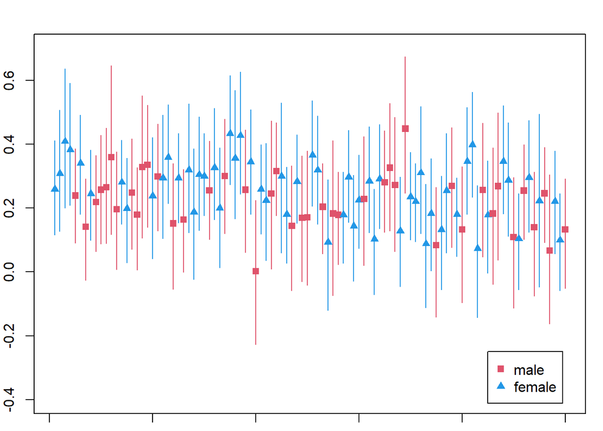

```r
gender <- datatest$genderf
ord <- order(datatest$age)
genderord <- gender[ord]
paord <- postallage[,ord]
par(mar=c(1,2,2,1))
plot(paord[2,],pch=16+genderord, col=genderord+3, ylim =c(-0.4,.7),xlab="",ylab="")
segments(1:ntest,paord[1,],1:ntest,paord[3,], col=genderord+3)
legend(85,-0.25,legend=c("male", "female"),pch=c(15,17),col=c(2,4))
```

### Shapley values

Needs means and (co-)variances, as computed from

```r
EXX <- cov(X1)
EX <- apply(X1,2,mean)
```

Covariate for which Shapley values are computed. May be a name (should match with that in the data set) or an index

```r
cov <- "age"
```

Compute Shapley values and intervals. Three components: 1: Total; 2: Contribution main effect; 3: contribution interactions.

```r
shapcov <- shapley(cov, Xtest ,EXX, EX,betapost,betapostint)
```

Plot Shapleys and 95% cred int for test samples ordered w.r.t. covariate values

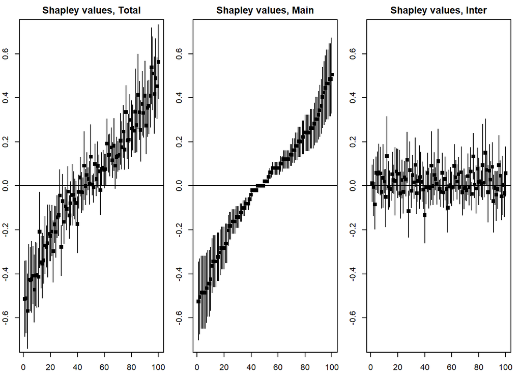

```r
par(mar=c(2,2,2,1),mfrow=c(1,3))
for(k in 1:3){
shapcovtot <- shapcov[[k]] #first component is total shapley value
whcov <- which(colnames(Xtest)==cov)
ord <- order(Xtest[,whcov])
covvalue <- Xtest[,whcov]
shord <- shapcovtot[ord,]
par(mar=c(2,2,2,1))
if(k==1) lab <- "Shapley values, Total"
if(k==2) lab <- "Shapley values, Main"
if(k==3) lab <- "Shapley values, Inter"
plot(shord[,2],pch=15, col=1,xlab="",ylim=c(-0.7,0.7),ylab="",main=lab)
segments(1:ntest,shord[,1],1:ntest,shord[,3], col=1)
abline(h=0)
}
```

Compute global variable importances from Shapleys across large test sample (I_j)

```r
ntestl <- 1000
subsettestl <- sample(1:nsam, ntestl)
datatestl <- datasynth[subsettestl,]
Xtestl <- as.matrix(datatest[,-1])
```

Plot global Shaps for all covariates

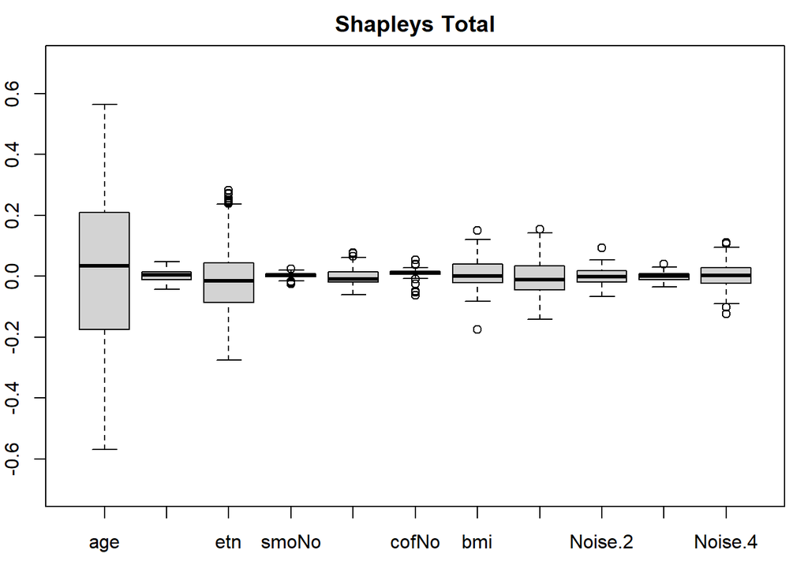

```r
allshap <- shapleys(X1, Xtestl, betapost,betapostint,grouped = list(etn=3:6))
allshapsum <- sapply(1:length(allshap), function(i) return(allshap[[i]]$tot[,2]))
colnames(allshapsum) <-  names(allshap)
par(mar=c(3,2,2,1))
boxplot(allshapsum, main="Shapleys Total",ylim = c(-0.7,0.7))
```

## Variations to Bayint

Bay0int: no shrinkage of main effects (vague prior)

```r
stan_lin0int_brl_HalfCauchy <- stan_model(model_name = "stan_lin0int_brl_HalfCauchy",
                                          model_code = code_lin0int_brl_HalfCauchy)
Bay0int <- suppressWarnings(sampling(stan_lin0int_brl_HalfCauchy, data = dat,
                                     iter = niter, warmup = nwarmup, thin = 10, chain = 1))
```

Bayintadd: additive model for shrinkage of interaction parameters

```r
stan_linintadd_brl_HalfCauchy <- stan_model(model_name = "stan_linintadd_brl_HalfCauchy",
                                            model_code = code_linintadd_brl_HalfCauchy)
Bayintadd <- suppressWarnings(sampling(stan_linintadd_brl_HalfCauchy, data = dat,
                                       iter = niter, warmup = nwarmup,  thin = 10, chain = 1))
```

Bayint*: no adaptive global shrinkage parameter (tau2int=1) for interaction parameters

```r
stan_linint2_brl_HalfCauchy <- stan_model(model_name = "stan_linint2_brl_HalfCauchy",
                                          model_code = code_linint2_brl_HalfCauchy)
dat <- list(y = Y1, X = Xmain, Xint = Xint, n = nrow(Xmain), p = p, q=q, tau2int=1, g=1:p, g1=g1, g2=g2)
Bayintstar <- suppressWarnings(sampling(stan_linint2_brl_HalfCauchy, data = dat,
                                        iter = niter, warmup = nwarmup, thin = 10, chain = 1))
```

## Alternative methods

### OLS

```r
lmsub <- lm(resp ~ ., data=data1)
summary(lmsub)
```

```
##
## Call:
## lm(formula = resp ~ ., data = data1)
##
## Residuals:
##      Min       1Q   Median       3Q      Max
## -2.57074 -0.59275 -0.00446  0.60293  2.71262
##
## Coefficients:
##                    Estimate Std. Error t value Pr(>|t|)
## (Intercept)        0.121208   0.091371   1.327  0.18499
## age                0.313159   0.068983   4.540  6.4e-06 ***
## genderf            0.015420   0.056884   0.271  0.78640
## etn1               0.150916   0.125409   1.203  0.22914
## etn2              -0.041126   0.161472  -0.255  0.79902
## etn3              -0.060699   0.150606  -0.403  0.68702
## etn4              -0.087530   0.094034  -0.931  0.35219
## smoNo             -0.074762   0.081847  -0.913  0.36126
## smoPY             -0.024955   0.091079  -0.274  0.78415
## cofNo             -0.003428   0.077965  -0.044  0.96494
## bmi                0.067776   0.061512   1.102  0.27082
## Noise.1            0.021751   0.050744   0.429  0.66829
## Noise.2            0.076398   0.054606   1.399  0.16213
## Noise.3            0.030896   0.054377   0.568  0.57005
## Noise.4           -0.009334   0.053433  -0.175  0.86137
## `age:genderf`      0.113754   0.038596   2.947  0.00329 **
## `age:etn1`         0.015589   0.080417   0.194  0.84633
## `age:etn2`        -0.130433   0.098262  -1.327  0.18471
## `age:etn3`         0.073797   0.084647   0.872  0.38354
## `age:etn4`        -0.063865   0.060898  -1.049  0.29458
## `age:smoNo`       -0.055088   0.055477  -0.993  0.32098
## `age:smoPY`       -0.011215   0.047930  -0.234  0.81504
## `age:cofNo`        0.084512   0.058478   1.445  0.14875
## `age:bmi`         -0.075610   0.036639  -2.064  0.03934 *
## `age:Noise.1`     -0.044080   0.035456  -1.243  0.21411
## `age:Noise.2`     -0.047200   0.037472  -1.260  0.20813
## `age:Noise.3`     -0.054068   0.038795  -1.394  0.16376
## `age:Noise.4`     -0.072357   0.034663  -2.087  0.03713 *
## `genderf:etn1`     0.005160   0.068983   0.075  0.94038
## `genderf:etn2`    -0.045430   0.093924  -0.484  0.62872
```

[output cut: 61 more lines]

```
## `bmi:Noise.2`      0.019106   0.035213   0.543  0.58756
## `bmi:Noise.3`     -0.009664   0.036421  -0.265  0.79081
## `bmi:Noise.4`      0.032206   0.036009   0.894  0.37135
## `Noise.1:Noise.2` -0.009608   0.030519  -0.315  0.75297
## `Noise.1:Noise.3`  0.030146   0.031185   0.967  0.33396
## `Noise.1:Noise.4` -0.010032   0.032884  -0.305  0.76039
## `Noise.2:Noise.3` -0.009535   0.030208  -0.316  0.75233
## `Noise.2:Noise.4`  0.005226   0.031331   0.167  0.86756
## `Noise.3:Noise.4`  0.009576   0.027834   0.344  0.73089
## ---
## Signif. codes:  0 '***' 0.001 '**' 0.01 '*' 0.05 '.' 0.1 ' ' 1
##
## Residual standard error: 0.924 on 900 degrees of freedom
## Multiple R-squared:  0.2156, Adjusted R-squared:  0.1293
## F-statistic: 2.499 on 99 and 900 DF,  p-value: 1.988e-12
```

Bayloc: Standard local shrinkage model

```r
stan_lin_brl_HalfCauchy <- stan_model(model_name = "stan_lin_brl_HalfCauchy",
                                      model_code = code_lin_brl_HalfCauchy)
nc <- ncol(X1)
dat <- list(y = Y1, X = X1, n = nrow(X1), p = nc, g=1:nc)
Bayloc <- suppressWarnings(sampling(stan_lin_brl_HalfCauchy, data = dat,
                                    iter = niter, warmup = nwarmup, thin = 10, chain = 1))
```

### ridge2

load mgcv, which is used to estimate 2 ridge penalties automatically

```r
library(mgcv)
ncov <- ncol(X1)
```

Retrieve number of main effects from column names X1

```r
cn <- colnames(X1)
mainint <- mapint(cn)
mains <- mainint[[1]]
ncovmain <- length(mains)
```

Create two penalty matrices, one for main effects, one for interactions

```r
whmain <- 1:ncovmain
whint <- (1:ncov)[-whmain]
diag1 <- rep(0,ncov);diag1[whmain] <- 1;diag2 <- rep(0,ncov);diag2[whint] <- 1;
PP2 <- list(X1=list(diag(diag1),diag(diag2)),sp=-1)
```

Fit with mgcv’s gam function

```r
ridge2 <- gam(Y1 ~ 1+X1,family="gaussian",paraPen=PP2,method="ML",scale=-1)
ridge2$sp #estimated penalties
```

```
##        X11        X12
##   93.12311 2608.95002
```

```r
summary(ridge2) #fit summary
```

```
##
## Family: gaussian
## Link function: identity
##
## Formula:
## Y1 ~ 1 + X1
##
## Parametric coefficients:
##                     Estimate Std. Error t value Pr(>|t|)
## (Intercept)       -0.0336146  0.0502116  -0.669  0.50336
## X1age              0.2235242  0.0352830   6.335 3.62e-10 ***
## X1genderf         -0.0021562  0.0325963  -0.066  0.94727
## X1etn1             0.1469103  0.0534074   2.751  0.00606 **
## X1etn2             0.0263834  0.0609026   0.433  0.66496
## X1etn3            -0.1338322  0.0544390  -2.458  0.01413 *
## X1etn4            -0.0425295  0.0461848  -0.921  0.35735
## X1smoNo            0.0238455  0.0404363   0.590  0.55552
## X1smoPY            0.0534938  0.0384138   1.393  0.16407
## X1cofNo           -0.0542016  0.0417946  -1.297  0.19499
## X1bmi              0.0399560  0.0345649   1.156  0.24798
## X1Noise.1          0.0615981  0.0314369   1.959  0.05035 .
## X1Noise.2          0.0371316  0.0313657   1.184  0.23677
## X1Noise.3          0.0226291  0.0313419   0.722  0.47046
## X1Noise.4         -0.0384600  0.0309894  -1.241  0.21488
## X1age:genderf      0.0214639  0.0157713   1.361  0.17385
## X1age:etn1         0.0069858  0.0172240   0.406  0.68514
## X1age:etn2        -0.0040401  0.0175176  -0.231  0.81765
## X1age:etn3        -0.0010564  0.0173023  -0.061  0.95133
## X1age:etn4        -0.0109588  0.0169813  -0.645  0.51886
## X1age:smoNo        0.0032519  0.0163994   0.198  0.84286
## X1age:smoPY       -0.0006947  0.0162855  -0.043  0.96599
## X1age:cofNo        0.0051370  0.0166521   0.308  0.75777
## X1age:bmi         -0.0251280  0.0157432  -1.596  0.11079
## X1age:Noise.1     -0.0013789  0.0156161  -0.088  0.92965
## X1age:Noise.2     -0.0167924  0.0157030  -1.069  0.28517
## X1age:Noise.3     -0.0089795  0.0156744  -0.573  0.56686
## X1age:Noise.4     -0.0157500  0.0153905  -1.023  0.30639
## X1genderf:etn1     0.0001139  0.0171836   0.007  0.99471
## X1genderf:etn2     0.0004165  0.0174754   0.024  0.98099
## X1genderf:etn3     0.0009962  0.0172938   0.058  0.95408
```

[output cut: 60 more lines]

```
## X1bmi:Noise.2      0.0056176  0.0157652   0.356  0.72167
## X1bmi:Noise.3     -0.0043574  0.0157060  -0.277  0.78150
## X1bmi:Noise.4      0.0035367  0.0156964   0.225  0.82178
## X1Noise.1:Noise.2 -0.0014419  0.0154124  -0.094  0.92548
## X1Noise.1:Noise.3  0.0050398  0.0154437   0.326  0.74424
## X1Noise.1:Noise.4 -0.0028973  0.0157130  -0.184  0.85375
## X1Noise.2:Noise.3 -0.0035523  0.0153356  -0.232  0.81687
## X1Noise.2:Noise.4  0.0029527  0.0155092   0.190  0.84905
## X1Noise.3:Noise.4  0.0057683  0.0149457   0.386  0.69962
## ---
## Signif. codes:  0 '***' 0.001 '**' 0.01 '*' 0.05 '.' 0.1 ' ' 1
##
##
## R-sq.(adj) =  0.119   Deviance explained = 14.2%
## -ML = 1368.3  Scale est. = 0.86384   n = 1000
```

### Two-step (add only two-way interactions of significant main effects)

Fit lm to model with main effects only

```r
Xmain <- X1[,mains]
cn <- colnames(X1)
ncovmain <- ncol(Xmain)
lmmain <- lm(Y1 ~ Xmain)
```

Extract significant main effects

```r
summ <- summary(lmmain)
pvalsmain <- summ$coefficients[-1,4]
whsig <- which(pvalsmain<=0.05)
datammsel <- data.frame(Xmain[,whsig,drop=FALSE])
```

Create model matrix with all two-way interactions of significant main effects

```r
mmsel <- model.matrix(~(.)^2, data=datammsel)[,-1,drop=FALSE]
matchcn <- match(colnames(mmsel), cn)
whna <- which(is.na(matchcn))
if(length(whna)>0) matchcn <- matchcn[-whna]
```

Fit final model

```r
lmtwostep <- lm(Y1 ~ . , data = data.frame(X1[,matchcn,drop=FALSE]))
```

Store match of selected columns with those of the original data frame, X1

```r
lmtwostep$matchcn <- matchcn
```

### lassoint (lasso penalty on interactions)

```r
library(glmnet)
whmain <- 1:ncovmain
whint <- (1:ncov)[-whmain]
```

penalty factors: 0 for main effects, 1 for interaction terms

```r
pf <- c(rep(0,length(whmain)),rep(1,length(whint)))
cvlasso1 <- cv.glmnet(X1,Y1, penalty.factor=pf)
print(cvlasso1)
```

```
##
## Call:  cv.glmnet(x = X1, y = Y1, penalty.factor = pf)
##
## Measure: Mean-Squared Error
##
##      Lambda Index Measure      SE Nonzero
## min 0.03641     9  0.8851 0.03598      25
## 1se 0.07664     1  0.8906 0.03725      14
```

Fit lasso and store optimal lambda

```r
lasso1 <- glmnet(X1,Y1, penalty.factor=pf)
lasso1$lambda.min <- cvlasso1$lambda.min
```

### hierarchical lasso

```r
library(glinternet)
Xmain <- X1[,mains]
ncovmain <- ncol(Xmain)
numLevels <- rep(1, ncovmain)
```

hlasso needs the interactionPairs. As we wish to exclude interactions between levels of the categorical variable, which represent dummies 3 to 6, this requires some programming. Below’s code creates all interactionPairs between covariates 1, .., 14 except those between 3, …, 6.

```r
catind <- c(3,6)
mat <- c() #interactions for hlasso
for(i in 1:(ncovmain-1)) for(j in (i+1):ncovmain) {
  cond <- (i >= catind[1]) & (i <= catind[2]) & (j >= catind[1]) & (j <= catind[2])
  if(!cond) mat <- rbind(mat,c(i,j))
}
print(mat)
```

```
##       [,1] [,2]
##  [1,]    1    2
##  [2,]    1    3
##  [3,]    1    4
##  [4,]    1    5
##  [5,]    1    6
##  [6,]    1    7
##  [7,]    1    8
##  [8,]    1    9
##  [9,]    1   10
## [10,]    1   11
## [11,]    1   12
## [12,]    1   13
## [13,]    1   14
## [14,]    2    3
```

[output cut: 71 more lines]

Fit and CV hlasso

```r
hlassocv <- glinternet.cv(Xmain, Y1, numLevels=rep(1,ncovmain),interactionPairs=mat)
proc.time()-pmt
```

```
##    user  system elapsed
## 1073.60    0.88 1264.45
```

## Retrieving coefficients

function to retrieve coefs from hlasso; a bit more tedious than for the methods

```r
coefshlasso <- function(cv,cndat,mat){
  betahat <- rep(0, length(cndat)+1)
  names(betahat) <- c("(Intercept)", cndat)
  betahat[1] <- cv$betahat[[1]][1]
  betahat[1 + coef(cv)$mainEffects$cont] <- unlist(coef(cv)$mainEffectsCoef$cont)
  interactions <- coef(cv)$interactions$contcont
  wh <- match(asplit(interactions,1),asplit(mat,1))
  betahat[1 + ncovmain + wh] <- unlist(coef(cv)$interactionsCoef$contcont)
  return(betahat)
}
```

Estimated coefficients for all methods (posterior means for Bayesian estimates)

```r
ncoef <- ncol(X1)
coefBayint <- summary(Bayint)$summary[4:(3+ncoef),1] #exclude intercept and 2 hyperparameters
coefBay0int <- summary(Bay0int)$summary[3:(2+ncoef),1];
coefBayintadd <- summary(Bayintadd)$summary[4:(3+ncoef),1]
coefBayintstar <- summary(Bayintstar)$summary[3:(2+ncoef),1]
coefols <- coef(lmsub)[-1] #exclude intercept
coefridge2 <- coef(ridge2)[-1] #exclude intercept
coefBayloc <- summary(Bayloc)$summary[3:(2+ncoef),1] #exclude intercept and hyperparameter
coeflassoint <- as.numeric(coef(lasso1,s=lasso1$lambda.min))[-1]
coefhlas <- coefshlasso(cv=hlassocv,cndat=colnames(X1),mat=mat)[-1]
whsel <- lmtwostep$matchcn
coef2step <- rep(0,ncoef)
coef2step[whsel] <- coef(lmtwostep)[-1]
allcoef <- data.frame(coefBayint,coefBay0int,coefBayintadd,coefBayintstar,coefols,
                      coefridge2, coefBayloc,coeflassoint,coefhlas,coef2step)
print(allcoef)
```

```
##                coefBayint   coefBay0int coefBayintadd coefBayintstar
## beta[1]      2.665482e-01  0.2569638042  0.2724127555   0.2831145060
## beta[2]      2.340880e-03  0.0104509748  0.0023984673   0.0011265205
## beta[3]      2.202236e-01  0.2127063482  0.1993612538   0.1518202166
## beta[4]      9.993555e-03  0.0278263898  0.0125978237  -0.0011374755
## beta[5]     -1.924598e-01 -0.2192936929 -0.1807979244  -0.1289868263
## beta[6]     -6.826007e-02 -0.0708463780 -0.0631296984  -0.0482300001
## beta[7]      6.505054e-03  0.0134874339  0.0080084092  -0.0025312984
## beta[8]      2.222993e-02  0.0267600577  0.0277326566   0.0091673644
## beta[9]     -3.142611e-02 -0.0532758000 -0.0298883621  -0.0125901469
## beta[10]     4.409322e-02  0.0611031224  0.0351683925   0.0223115439
## beta[11]     5.254861e-02  0.0632129270  0.0533724008   0.0208716662
## beta[12]     2.849026e-02  0.0447344663  0.0285997104   0.0094332394
## beta[13]     1.137796e-02  0.0317144337  0.0150862002   0.0036015874
## beta[14]    -3.475570e-02 -0.0340047470 -0.0336440849  -0.0120014791
## betaint[1]   3.703770e-02  0.0510455129  0.0553155034   0.0569176486
## betaint[2]   3.834648e-02  0.0375584449  0.0325024869   0.0560012795
## betaint[3]  -1.843068e-02 -0.0410571621 -0.0219739568  -0.0503612429
## betaint[4]  -8.074437e-03 -0.0015786453 -0.0042443026   0.0119511306
## betaint[5]  -5.170141e-02 -0.0661894940 -0.0494778352  -0.0795490363
## betaint[6]  -1.867577e-03 -0.0027541943 -0.0074188900  -0.0017223760
## betaint[7]  -2.296039e-03 -0.0028203915 -0.0021431875  -0.0005371098
## betaint[8]   2.574133e-02  0.0298041926  0.0353413918   0.0524069462
## betaint[9]  -6.154448e-02 -0.0722235363 -0.0632054509  -0.0739419481
## betaint[10] -2.283656e-03 -0.0044203813 -0.0038444670  -0.0126839558
## betaint[11] -3.101952e-02 -0.0331302344 -0.0401190908  -0.0408347210
## betaint[12] -1.166483e-02 -0.0135356507 -0.0249826694  -0.0260799962
## betaint[13] -3.537329e-02 -0.0446976757 -0.0404733043  -0.0427757539
## betaint[14] -5.846157e-04 -0.0017754752  0.0009793545   0.0004316992
## betaint[15]  9.338339e-06 -0.0026975106 -0.0009387352  -0.0030058817
## betaint[16]  3.248500e-03  0.0057863124  0.0040328186   0.0052908903
## betaint[17]  2.150315e-03  0.0063134852  0.0026541228   0.0045980240
## betaint[18] -7.447777e-04 -0.0013880003 -0.0001190583  -0.0009536941
## betaint[19] -2.217836e-03 -0.0042323347 -0.0045297635  -0.0046523149
## betaint[20] -4.757149e-03 -0.0054515150 -0.0066558028  -0.0088053576
## betaint[21] -3.823938e-03 -0.0047081177 -0.0037235412  -0.0052689952
## betaint[22] -1.511227e-03 -0.0005374571 -0.0008800750  -0.0004513538
## betaint[23]  3.598680e-03  0.0051198829  0.0045774019   0.0047954157
## betaint[24]  1.549458e-04  0.0014553739  0.0013699828   0.0007051699
## betaint[25] -4.256792e-03 -0.0063913028 -0.0026051635  -0.0069862761
```

[output cut: 245 more lines]

```
## betaint[71]  0.000000000
## betaint[72]  0.000000000
## betaint[73]  0.000000000
## betaint[74]  0.000000000
## betaint[75]  0.000000000
## betaint[76]  0.000000000
## betaint[77]  0.000000000
## betaint[78]  0.000000000
## betaint[79]  0.000000000
## betaint[80]  0.000000000
## betaint[81]  0.000000000
## betaint[82]  0.000000000
## betaint[83]  0.000000000
## betaint[84]  0.000000000
## betaint[85]  0.000000000
```